# roastgsa vignette (main)

Adria Caballe-Mestres

15 August 2023

# 1 Installation

```r
if (!require("BiocManager", quietly = TRUE))
    install.packages("BiocManager")
BiocManager::install("roastgsa")
```

# 2 Paper associated to R package

```r
library( roastgsa )
```

The R package `roastgsa` contains several functions to perform gene set analysis, for both competitive and self-contained hypothesis testing.

It follows the work by Gordon Smyth’s group on rotation based methods for gene set analysis [1], code available in R through functions `roast` and `romer` from the `limma` package [2].

They propose to reconsider the sample randomization approach based on permutations of GSEA [3] to the more general procedure scheme using rotations of the residual space of the data, which can be used even when the number of degrees of freedom left is very small.

In our understanding, the test statistics provided in `romer`, which are all functions of the moderated t-statistics ranks, are too limited. In this R package we propose to complete the romer functionality by providing other statistics used in the GSA context [4]. We consider the KS based test statistics in the GSEA and GSVA [5] as well as computationally more efficient procedures such as restandardized statistics based on summary statistics measures. The methodology is presented and compared using both simulated and benchmarking data in the following publication:

roastgsa: a comparison of rotation-based scores for gene set enrichment analysis (2023).

We encourage anybody wanting to use the R package to first read the associated paper.

In this R package, we have also provided several tools to summarize and visualize the roastgsa results. This vignette will show a work-flow for gene set analysis with `roastgsa` using microarray data (available in the `GSEABenchmarkeR` R package [6]).

# 3 Data: array experiment from GSEABenchmarkeR

We consider the fourth dataset available in the `GSEABenchmarkeR` R package, which consists of a microarray study with 30 samples, 15 paired samples corresponding to two different groups (that take values 0 and 1 respectively).

```r
library(GSEABenchmarkeR)
geo2keggR <- loadEData("geo2kegg", nr.datasets=4)
geo2kegg <- maPreproc(list(geo2keggR[[4]]))
y <- assays(geo2kegg[[1]])$expr
covar <- colData(geo2kegg[[1]])
covar$GROUP <- as.factor(covar$GROUP)
covar$BLOCK <- as.factor(covar$BLOCK)
```

The objective is to understand which KEGG processes might be affected by such two genotyping conditions. These are made available through the `EnrichmentBrowser` R package. Here we will consider gene sets of size between 11 and 499.

```r
#library(EnrichmentBrowser)
#kegg.hs <- getGenesets(org="hsa", db="kegg")
data(kegg.hs)
kegg.gs <- kegg.hs[which(sapply(kegg.hs,length)>10&sapply(kegg.hs,length)<500)]
```

# 4 Gene set enrichment analysis using roastgsa

## 4.1 Data treatment

There are some important elements that should be taken into consideration before undertaking the `roastgsa`. First, the expression data should be approximately normally distributed, at least in their univariate form. For RNA-seq data or any other form of counts data, prior normalization, e.g., `rlog` or `vst` (`DESeq2`), `zscoreDGE` (`edgeR`) or `voom` (`limma`), should be used. Besides, filtering for expression intensity and variability could be considered, especially when the gene variation across individuals is limited by the experimental coverage.

For microarray intensities, as it happens in the example of this vignette, we can perform a quantile normalization to balance out the libraries.

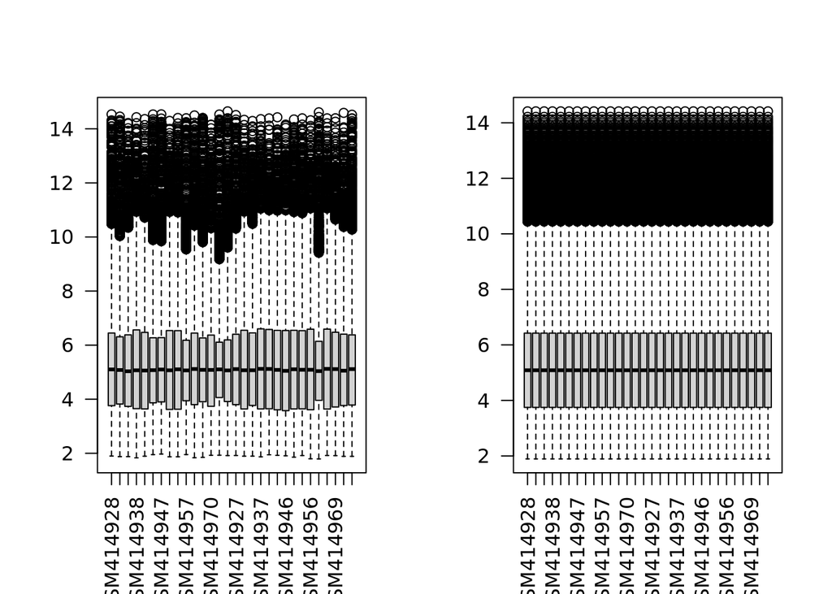

```r
library(preprocessCore)
ynorm <- normalize.quantiles(y)
rownames(ynorm) <- rownames(y)
colnames(ynorm) <- colnames(y)
par(mfrow=c(1,2))
boxplot(y, las = 2)
boxplot(ynorm, las = 2)
```

```r
y <- ynorm
```

## 4.2 Model setting

Indicating the model to be fitted is essential for the roastgsa implementation. This follows a similar strategy to the `limma` specifications. With the attributes `form`, `covar` and `contrast` it can be set the linear model and the specific estimated coefficient to be used in `roastgsa` for hypothesis testing. The matrix design is found automatically taking the `form` and `covar` parameters (see below). The `contrast` can be in a vector object (length equal to the number of columns in the matrix design), an integer with the column of the term of interest in the matrix design, as well as the name of such column.

```r
form = as.formula("~ BLOCK + GROUP")
design <- model.matrix(form, covar)
contrast = "GROUP1"
```

Three parameters that define the roast hypothesis testing have to be properly specified: -a- the number of rotations to draw the null hypothesis (`nrot`); -b- the statistic to be used (`set.statistic`); -c- the type of hypothesis (`self.contained` argument), competitive (set to FALSE) or self-contained (set to TRUE).

Regarding the test statistics, the `maxmean` (directional) and the `absmean` (nondirectional) are recommended to maximise the power, with `mean.rank` being a good non-parametric alternative for a more robust statistic if it is known that a few highly differentially expressed genes might influence heavily the statistic calculation. For a more “democratic” statistic, one that counterbalance both ends of the distribution (negative and positive), we encourage using the `mean` statistic.

Below, there is the standard `roastgsa` instruction (under competitive testing) for `maxmean` and `mean.rank` statistics.

```r
fit.maxmean.comp <- roastgsa(y, form = form, covar = covar,
contrast = contrast, index = kegg.gs, nrot = 500,
mccores = 1, set.statistic = "maxmean",
self.contained = FALSE, executation.info = FALSE)
f1 <- fit.maxmean.comp$res
rownames(f1) <- substr(rownames(f1),1,8)
head(f1)
```

```
##          total_genes measured_genes       est      nes        pval   adj.pval
## hsa05230          70             69 0.5426062 3.791650 0.001996008 0.04747648
## hsa04215          32             31 0.6704318 3.366828 0.001996008 0.04747648
## hsa04520          93             92 0.6180931 3.330555 0.001996008 0.04747648
## hsa04115          73             73 0.8054489 3.309838 0.001996008 0.04747648
## hsa04530         169            164 0.4898548 3.280710 0.005988024 0.08669617
## hsa05412          77             77 0.4804075 3.206732 0.001996008 0.04747648
```

```r
fit.meanrank <- roastgsa(y, form = form, covar = covar,
    contrast = 2, index = kegg.gs, nrot = 500,
    mccores = 1, set.statistic = "mean.rank",
    self.contained = FALSE, executation.info = FALSE)
f2 <- fit.meanrank$res
rownames(f2) <- substr(rownames(f2),1,8)
head(f2)
```

```
##          total_genes measured_genes       est  pval.diff adj.pval.diff
## hsa04012          85             84  2215.012 0.00998004      0.999008
## hsa04710          34             33  2527.909 0.01397206      0.999008
## hsa00230         128            124 -1624.024 0.02195609      0.999008
## hsa00220          22             21  4325.095 0.07385230      0.999008
## hsa05213          58             58  2279.379 0.07784431      0.999008
## hsa05223          72             72  1851.514 0.07784431      0.999008
##           pval.mixed adj.pval.mixed
## hsa04012 0.051896208      0.5738164
## hsa04710 0.483033932      0.7117270
## hsa00230 0.363273453      0.6434578
## hsa00220 0.061876248      0.5738164
## hsa05213 0.001996008      0.1329341
## hsa05223 0.047904192      0.5738164
```

## 4.3 Visualization of the results

Several functions to summarize or visualize the results can be applied to objects of class `roastgsa`, which are found as output of the `roastgsa` function.

The `plot` function of a `roastgsa` object produces a general image of the differential expression results within any tested gene set. If `type = "stats"`, it shows the ordered moderated t-statistics in various formats, area for up- and down- expressed genes, barcode plot for these ordered values and density. With the argument `whplot` it can be selected the gene set of interest (either an integer with the ordered position in the roastgsa output or the name of the gene set).

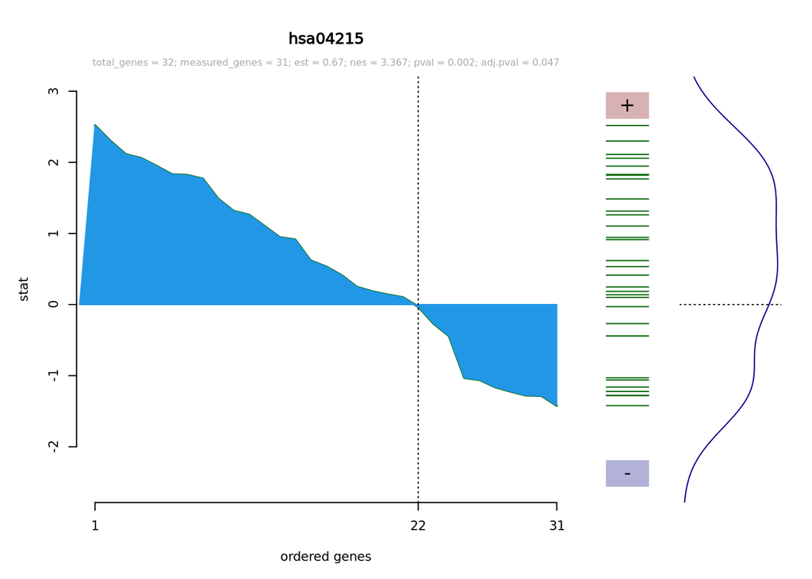

```r
plot(fit.maxmean.comp, type ="stats", whplot = 2,  gsainfo = TRUE,
    cex.sub = 0.5, lwd = 2)
```

If the `roastgsa` statistic is `mean.rank`, the moderated-t statistic centred ranks are printed instead.

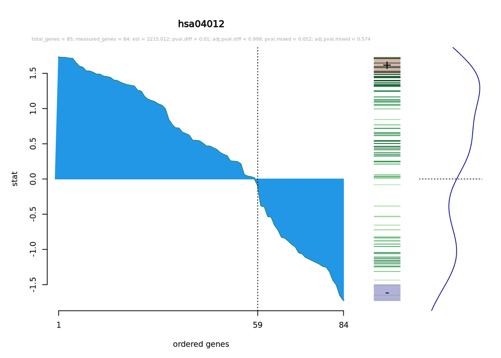

```r
plot(fit.meanrank,  type ="stats",  whplot = 1, gsainfo = TRUE,
    cex.sub = 0.4, lwd = 2)
```

Even though the `type = "GSEA"` option is directly interpretable for ksmean and ksmax statistics, we find it useful for seeing the behavior in both Kolgomorov-Smirnov type scores and simple summary statistics:

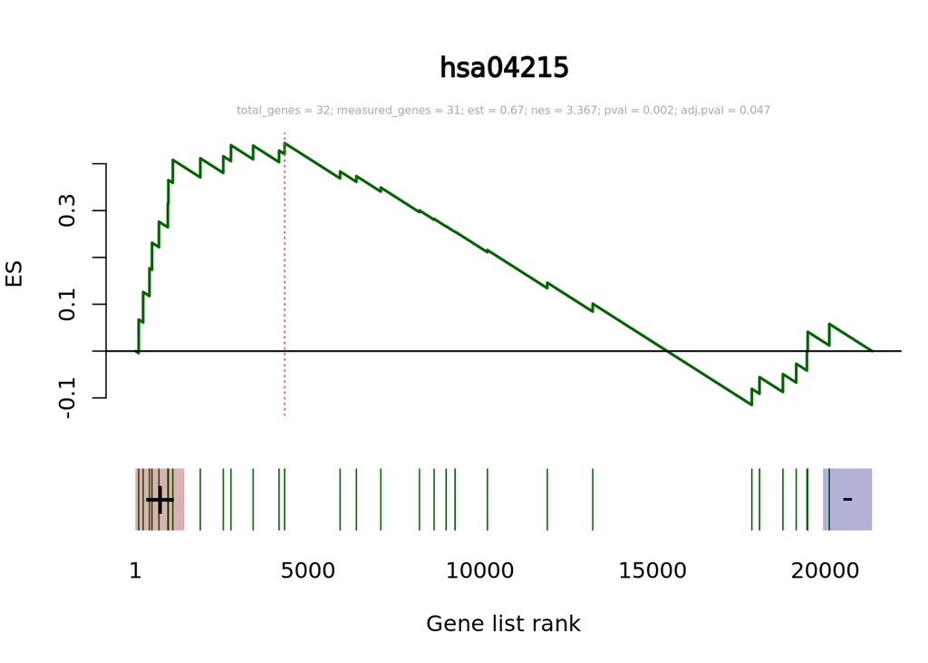

```r
plot(fit.maxmean.comp, type = "GSEA", whplot = 2, gsainfo = TRUE,
    maintitle = "",  cex.sub = 0.5, statistic = "mean")
```

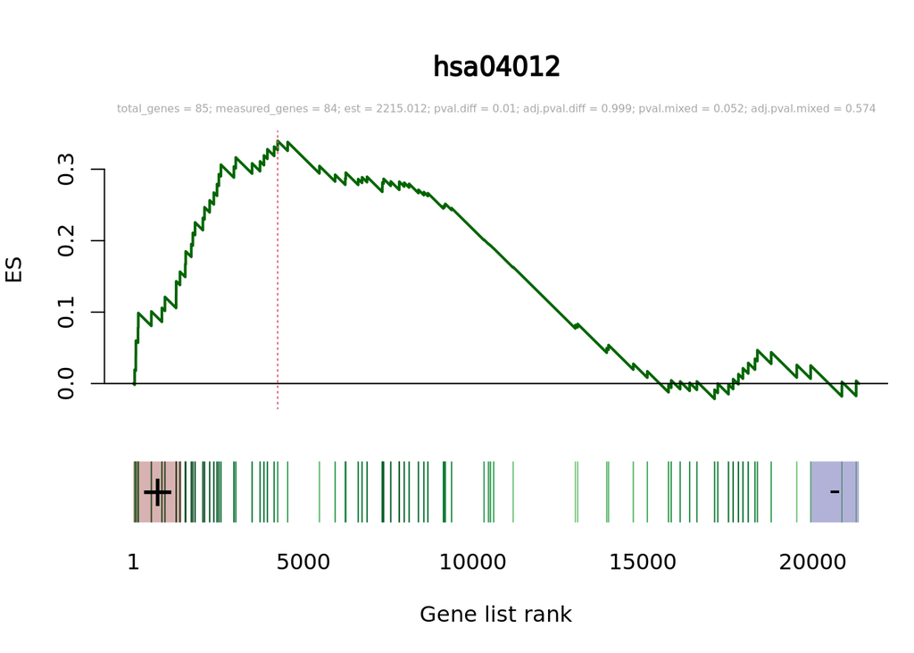

```r
plot(fit.meanrank, type = "GSEA",  whplot = 1, gsainfo = TRUE,
    maintitle = "",  cex.sub = 0.5, statistic = "mean")
```

Another graphic that is proposed in this package to visualize the genes activity within a gene set can be obtained through the function `heatmaprgsa_hm`. The main intention is to illustrate the variation across samples for the gene set of interest. We highly recommend the generation of this graphic, or any other similar plot that shows sample variation for the tested gene sets. Not only for showing which genes are activated but also as quality control to detect samples that can be highly influential in the GSA analysis.

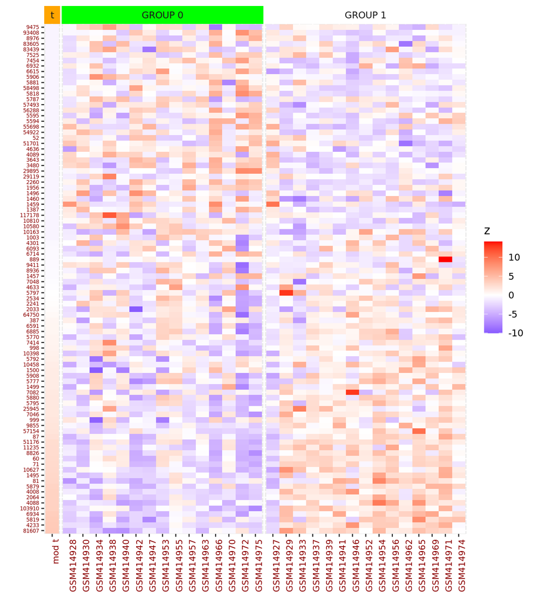

```r
hm <- heatmaprgsa_hm(fit.maxmean.comp, y, intvar = "GROUP", whplot = 3,
        toplot = TRUE, pathwaylevel = FALSE, mycol = c("orange","green",
        "white"), sample2zero = FALSE)
```

The same sort of graphic can be drawn at pathway level, i.e., summarized (average) pathway activity, when `pathwaylevel = TRUE`. With the parameter `whplot` it can be specified which pathways are included in the comparison.

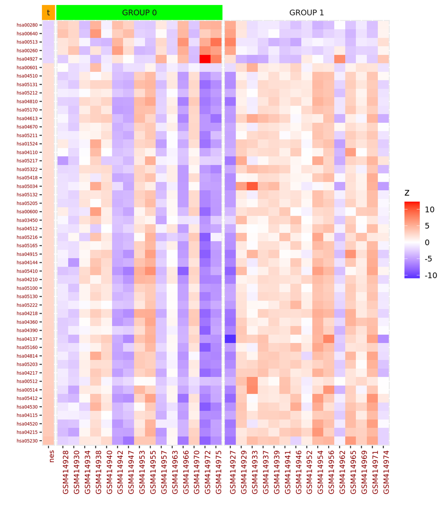

```r
hm2 <- heatmaprgsa_hm(fit.maxmean.comp, y, intvar = "GROUP", whplot = 1:50,
        toplot = TRUE, pathwaylevel = TRUE, mycol = c("orange","green",
        "white"), sample2zero = FALSE)
```

## 4.4 Effective signature size

Gene sets in standard databases might contain from moderately to highly correlated genes, even when the effect of the known covariates is adjusted a priori. The variance of summary statistics such as mean or maxmean increases with the intra-gene set correlation, meaning that the power for detecting gene set changes between experimental conditions depends on a combination of genewise effect sizes, signature size and intra-gene set correlation.

We define the effective signature size of a tested gene set by the total number of genes that are needed, if these were selected at random, to achieve the same summary statistic variance as that for the testing set. This can be viewed as a realistic measure of the total number of independent variables that contribute to the power of the test. To get an estimate of the effective signature size, sample variances of rotation scores for randomly generated sets of several sizes are compared to the observed rotation scores variance for the tested gene set:

```r
## Computationally intensive
# varrot <- varrotrand(fit.maxmean.comp, y,
#   testedsizes = c(3:30, seq(32,50, by=2), seq(55,200,by=5)), nrep = 200)
```

A p-value that approximates the probability of obtaining a variance as extreme as the observed test variance in randomly selected sets of several sizes is computed:

```r
# ploteffsignaturesize(fit.maxmean.comp, varrot,  whplot = 1)
```

## 4.5 Functions to present the results

The outcome obtained in `roastgsa` can be organized in a html table using the `htmlrgsa` function. The reported file shows all numerical results that can be found in printing an object of class `roastgsa` as well as the plots obtained by `plotStats`, `plotGSEA`, `heatmaprgsa_hm` or `varrotrand` + `ploteffsignaturesize`. A column with html-links for the differential expression results at gene level can also be provided through the argument `geneDEhtmlfiles`, which we find extremely useful for researchers to understand which are the genes that drive the pathway activity.

```r
#htmlrgsa(fit.maxmean.comp, htmlpath = getwd(), htmlname = "file.html",
#  plotpath = paste0(getwd(),"/plotsroast/"), geneDEhtmlfiles = NULL,
#  plotstats = TRUE, plotgsea = TRUE, indheatmap = TRUE,
#  ploteffsize = TRUE, y = y, intvar = "GROUP", whplot = 1:50,
#  mycol = c("orange","green","white"), varrot=varrot,
#  sorttable = sorttable,dragtable = dragtable)
```

Complete information on the usage of this function can be found in the manual.

## 4.6 Single sample GSA

To complement the outcome of the `roastgsa`, we encourage the usage of single sample GSA visualization methods. These approaches are interesting for assessing the variability of gene set effects at sample level (averaging out gene wise coefficients) instead of at gene level.

The `heatmaprgsa_hm` instruction used above already provides some insight of sample variation. Besides, in the `roastgsa` package we have implemented a function for single sample gene set analysis based on z-scores [7]. We present two methods that correct for the overall structure in the genome (`method = "GScor"` and `method = "GSadj"`), leading to competitive testing, and one method that ignores the rest of the genes in the data (`method = "zscore"`), self-contained testing. For small sample sizes, we recommend using “GScor” whereas for sufficiently large sample size (>50) “GSadj” is our preferred option.

```r
ss1 <- ssGSA(y, obj=fit.maxmean.comp, method = c("GScor"))
```

Visualizing the summarized gene set information at sample level is highly recommended to check the variation of the samples in the groups of interest.

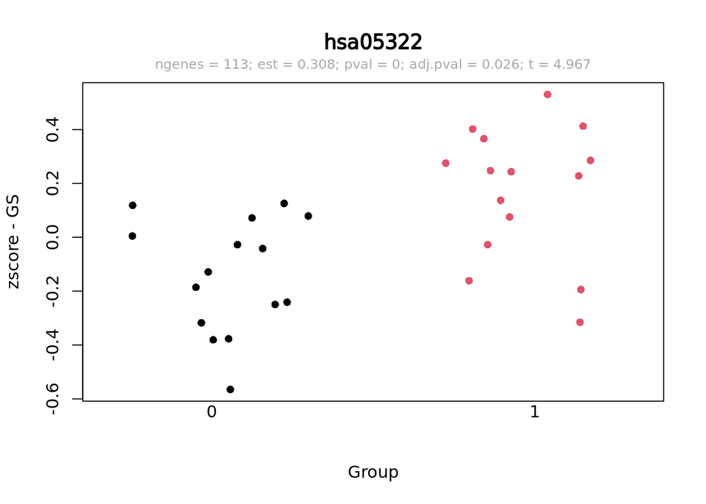

```r
plot(ss1, orderby = covar$GROUP, whplot = 1, col = as.numeric(covar$GROUP),
samplename = FALSE, pch =16, maintitle = "", ssgsaInfo = TRUE,
cex.sub = 0.8, xlab = "Group", ylab = "zscore - GS")
```

# 6 References

# Appendix

[1] E. Lim, D. Wu, G. K. Smyth, M.-L. Asselin-Labat, F. Vaillant, and J. E. Visvader. ROAST: rotation gene set tests for complex microarray experiments. Bioinformatics, 26(17):2176-2182, 2010.

[2] M. E. Ritchie, B. Phipson, D. Wu, Y. Hu, C. W. Law, W. Shi, and G. K. Smyth. limma powers differential expression analyses for RNAsequencing and microarray studies. Nucleic acids research, 43(7):e47, 2015.

[3] A. Subramanian, P. Tamayo, V. K. Mootha, S. Mukherjee, B. L. Ebert, M. A. Gillette, A. Paulovich, S. L. Pomeroy, T. R. Golub, E. S. Lander, and J. P. Mesirov. Gene set enrichment analysis: A knowledge-based approach for interpreting genome-wide expression profiles. Proceedings of the National Academy of Sciences, 102(43):15545-15550, 2005.

[4] B. Efron and R. Tibshirani. On testing the significance of sets of genes. The Annals of Applied Statistics, 1(1):107-129, 2007.

[5] S. Hanzelmann, R. Castelo, and J. Guinney. GSVA: gene set variation analysis for microarray and RNA-Seq data. 14(1):7, 2013.

[6] Geistlinger L, Csaba G, Santarelli M, Schiffer L, Ramos M, Zimmer R, Waldron L (2019). GSEABenchmarkeR: Reproducible GSEA Benchmarking. R package version 1.6.0, https://github.com/waldronlab/GSEABenchmarkeR.

[7] Caballe Mestres A, Berenguer Llergo A and Stephan-Otto Attolini C. Adjusting for systematic technical biases in risk assessment of gene signatures in transcriptomic cancer cohorts. bioRxiv (2018).